# MDML_Final_Project_YJ_FT_OC

Yeonji Jung, Frankie Tam, Ofer Chen

# Descriptions

## BACKGROUND

Hints are an important learning aid. But students may have a tendency to use hints inappropriately. Offering hints indiscriminately can result in poor learning performance. For teachers to decide whether to show a hint or scaffolding to students in the further iteration, a prediction model on student hint-taking behaviors can be used to make adaptive decisions on whether to withhold or provide hints.

## DATA

The dataset is the ASSISTments’ skill builder problem sets data that gathered in the school year 2009 and 2010. ASSISTments is an online tutoring system that teachers can use to teach middle-school level Mathematics and identify student activities solving exercises on the system.

The dataset consists of log data of student activities including the chronological order of attempts (order_id), assignment id, problem id, user id, whether the first attempt is correct (correct), whether the number of attempts on the problem (attempt_count), the number of using hints on the problem (hint_count), whether or not the student asks for all hints (bottom_hint), the time in milliseconds for the student to complete the problem (overlap_time), time between start time and first student action (first_response_time), whether the first action is attempt, using hint, or using scaffolding (first_action). Each row represents a single problem of each student.

The dataset has the following features: (a) questions are based on one specific skill, a question can have multiple skill taggings. (b) students must answer three questions correct in a row to complete the assignment (c) if a student uses the tutoring (“hint” or “scaffolding”), the question will be marked incorrect (d) students will know immediately if they answered the question correctly (e) scaffolding means whether student asks for the problem to be broken into steps (f) The bottom out hint is the last hint for a problem and will generally contain the problem’s answer.

The raw dataset is available at https://sites.google.com/site/assistmentsdata/home/assistment-2009-2010-data/skill-builder-data-2009-2010.

## PURPOSE

Building a prediction model on student actions on next question (a) whether students will take a hint at first attempt (first_action) (b) whether students will take a bottom-out hint (bottom_hint) (c) whether students will answer correctly without hints (correct)

## APPROACH

# Part A: Import and Clean the Data

## Import packages and data

```r
#load packages
library(tidyverse)
library(randomForest)
library(doParallel)
library(foreach)
library(car)
library(ROCR)
library(leaps)
library(psych)
#import the data
df_raw <- read.csv("skill_builder_data.csv")
```

[output not shown]

## Clean the data

```r
#filter the following values
##("original") scaffolding problems (0); this is not relevant to this project
##("first_action") empty values; student clicked on the problem but did nothing else
##("first_action") scaffolding values; scaffolding opportunities varied across problem sets
##("answer_type") open_response; this type of answers always marked correct
##("tutor_mode") Tutor or test mode; students did not take any hints on test mode
##("ms_first_response") negative values and zero
##("overlap_time") negative values and zero
df_clean <- df_raw %>%
  filter(original==1, first_action!=2, !is.na(first_action),
         answer_type!="open_response", tutor_mode=="tutor", ms_first_response > 0, overlap_time > 0) %>%
  rename(problem_type = type)
#revalue the following columns:
##("bottom_hint") replace empty values into 0; it means the student did not ask for a hint
df_clean$bottom_hint[is.na(df_clean$bottom_hint)] <- 0
##Removing the skill_id and skill_name columns and merging identical rows
df_clean <- df_clean %>% select(-skill_id, -skill_name)
df_clean <- subset(df_clean,!duplicated(df_clean$order_id))
```

## Feature engineering; make historical features

```r
#Create a tibble with each order's previous orders
orders_a <- df_clean[,c(1,3)]
orders_b <- df_clean[,c(1,3)]
names(orders_a) <- c("order_id.x", "user_id")
names(orders_b) <- c("order_id.y", "user_id")
orders <- left_join(orders_a,orders_b, by = "user_id") %>% filter(order_id.y < order_id.x)
df_col <- df_clean[c('user_id', 'order_id', 'problem_id', 'correct', 'hint_count', 'hint_total', 'bottom_hint', 'ms_first_response', 'attempt_count')]
df_join <- left_join(orders, df_col, by=c("user_id", "order_id.y" = "order_id"))
df_hist <- df_join %>% group_by(order_id.x) %>%
  summarise(prev_total_correct = sum(correct),
            prev_num_problem = length(unique(problem_id)),
            prev_percent_correct=prev_total_correct/prev_num_problem,
            prev_questions_with_hints = sum(hint_total>0),
            prev_total_hints = sum(hint_total),
            prev_avg_hints_per_problem = prev_total_hints/prev_questions_with_hints,
            prev_problem_requested_hint = sum(hint_count>0),
            prev_percent_problem_requested_hint = prev_problem_requested_hint/prev_num_problem,
            prev_avg_response_time = mean(ms_first_response),
            prev_total_bottom_hint = sum(bottom_hint == 1),
            prev_percent_bottom_hint = prev_total_bottom_hint/prev_questions_with_hints,
            prev_avg_attempt_count = mean(attempt_count))
df_hist <- replace(df_hist, is.na(df_hist), 0)
df_fin <-  left_join(df_hist, df_clean, by = c("order_id.x" = "order_id"))
## we only keep the attemps by students who previously attempted; we hope to draw implications from historical features' coefficients on further hint-taking behaviors
#convert to factors
df_fin <- df_fin %>% mutate_at(vars(first_action,correct,bottom_hint,problem_id,teacher_id, school_id),funs(as.factor))
```

# Part B: Hint-Taking Prediction Model

## Create a training Set / test Set

```r
#randomly shuffle the data and removing questions with no option to get a hint
set.seed(1314)
df_hint <- df_fin %>% slice(sample(1:n())) %>% filter(hint_total>0)
#create train_half and test_half
splitsize = floor(nrow(df_hint)/2)
train <- df_hint %>% slice(1:splitsize)
test <- df_hint %>% slice(splitsize+1:n())
```

## Forward stepwise selection for features selection

```r
# forward stepwise selection
regfit.fa.fwd = regsubsets(first_action ~  prev_total_correct +
                          prev_percent_correct + prev_problem_requested_hint +
                          prev_percent_problem_requested_hint + prev_avg_response_time +
                          prev_total_bottom_hint + prev_percent_bottom_hint +
                          prev_avg_attempt_count, data=train, method="forward")
reg_fa_summary = summary(regfit.fa.fwd)
reg_fa_summary
```

```
Subset selection object
Call: regsubsets.formula(first_action ~ prev_total_correct + prev_percent_correct +
    prev_problem_requested_hint + prev_percent_problem_requested_hint +
    prev_avg_response_time + prev_total_bottom_hint + prev_percent_bottom_hint +
    prev_avg_attempt_count, data = train, method = "forward")
8 Variables  (and intercept)
                                    Forced in Forced out
prev_total_correct                      FALSE      FALSE
prev_percent_correct                    FALSE      FALSE
prev_problem_requested_hint             FALSE      FALSE
prev_percent_problem_requested_hint     FALSE      FALSE
prev_avg_response_time                  FALSE      FALSE
prev_total_bottom_hint                  FALSE      FALSE
prev_percent_bottom_hint                FALSE      FALSE
prev_avg_attempt_count                  FALSE      FALSE
1 subsets of each size up to 8
Selection Algorithm: forward
         prev_total_correct prev_percent_correct prev_problem_requested_hint prev_percent_problem_requested_hint
1  ( 1 ) " "                " "                  " "                         "*"
2  ( 1 ) " "                " "                  " "                         "*"
3  ( 1 ) "*"                " "                  " "                         "*"
4  ( 1 ) "*"                " "                  "*"                         "*"
5  ( 1 ) "*"                " "                  "*"                         "*"
6  ( 1 ) "*"                " "                  "*"                         "*"
7  ( 1 ) "*"                " "                  "*"                         "*"
8  ( 1 ) "*"                "*"                  "*"                         "*"
         prev_avg_response_time prev_total_bottom_hint prev_percent_bottom_hint prev_avg_attempt_count
1  ( 1 ) " "                    " "                    " "                      " "
2  ( 1 ) " "                    " "                    "*"                      " "
3  ( 1 ) " "                    " "                    "*"                      " "
4  ( 1 ) " "                    " "                    "*"                      " "
5  ( 1 ) " "                    "*"                    "*"                      " "
6  ( 1 ) "*"                    "*"                    "*"                      " "
7  ( 1 ) "*"                    "*"                    "*"                      "*"
8  ( 1 ) "*"                    "*"                    "*"                      "*"
```

## Examine the results of stepwise selection and identify optimal number of features

```r
test.mat = model.matrix(first_action ~ prev_total_correct +
                          prev_percent_correct + prev_problem_requested_hint +
                          prev_percent_problem_requested_hint + prev_avg_response_time +
                          prev_total_bottom_hint + prev_percent_bottom_hint +
                          prev_avg_attempt_count, data=test)
val.errors=rep(NA,8)
for (i in 1:8){
  coefi=coef(regfit.fa.fwd, id=i)
  pred=test.mat[,names(coefi)]%*%coefi
  val.errors[i]=mean((as.integer(test$first_action)-pred)^2)
}
val.errors
```

```
[1] 0.07620492 0.07528002 0.07523738 0.07512596 0.07509304 0.07507615 0.07509537 0.07508922
```

```r
which.min(val.errors)
```

```
[1] 6
```

## Plotting the results of forward stepwise selection

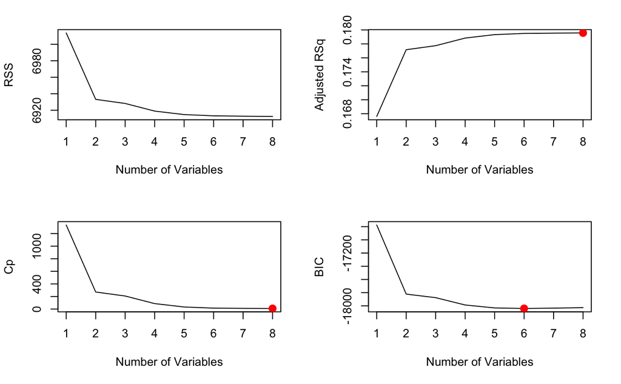

```r
# plots to examine RSS, R2, Cp and BIC
par(mfrow=c(2,2))
{plot(reg_fa_summary$rss, xlab = "Number of Variables", ylab = "RSS", type = "l")
plot(reg_fa_summary$adjr2, xlab = "Number of Variables", ylab = "Adjusted RSq", type = "l")
adj_r2_max = which.max(reg_fa_summary$adjr2)
points(adj_r2_max, reg_fa_summary$adjr2[adj_r2_max], col ="red", cex = 2, pch = 20)
plot(reg_fa_summary$cp, xlab = "Number of Variables", ylab = "Cp", type = "l")
cp_min = which.min(reg_fa_summary$cp) # 10
points(cp_min, reg_fa_summary$cp[cp_min], col = "red", cex = 2, pch = 20)
plot(reg_fa_summary$bic, xlab = "Number of Variables", ylab = "BIC", type = "l")
bic_min = which.min(reg_fa_summary$bic) # 6
points(bic_min, reg_fa_summary$bic[bic_min], col = "red", cex = 2, pch = 20)}
```

## Drop the lowest performing predictors based on forward stepwise selection results and fit the data to the logistic regression model

```r
#fit a logistic regression model on train using 5 features based on forward stepwise selection
# prev_total_correct
# prev_problem_requested_hint,
# prev_percent_problem_requested_hint
# prev_avg_response_time
# prev_percent_bottom_hint
re_lg_hint <- glm(first_action ~prev_total_correct +
                          prev_problem_requested_hint +
                          prev_percent_problem_requested_hint + prev_avg_response_time +
                          prev_percent_bottom_hint,
                  data=train, family="binomial")
#compute AUC of this model on the test dataset
test$re.lg.hint.pred.prob <- predict(re_lg_hint,newdata=test,type='response')
test.re.lg.hint.pred <- prediction(test$re.lg.hint.pred.prob, test$first_action)
test.re.lg.hint.perf <- performance(test.re.lg.hint.pred, "auc")
cat('the auc score is ', 100*test.re.lg.hint.perf@y.values[[1]], "\n")
```

```
the auc score is  80.66347
```

```r
#calculate the five smallest and five largest coefficients
re_lg_hint_coef <- summary(re_lg_hint)[["coefficients"]]
re_lg_hint_coef[order(re_lg_hint_coef[ , 1]), ]
```

```
                                         Estimate   Std. Error     z value      Pr(>|z|)
(Intercept)                         -3.054149e+00 2.662864e-02 -114.694139  0.000000e+00
prev_total_correct                  -3.006568e-03 1.802844e-04  -16.676809  1.932710e-62
prev_avg_response_time              -1.505304e-06 2.767869e-07   -5.438495  5.373265e-08
prev_problem_requested_hint          1.144910e-02 5.345267e-04   21.419135 8.861974e-102
prev_percent_bottom_hint             1.588750e+00 7.731958e-02   20.547839  8.046701e-94
prev_percent_problem_requested_hint  2.729831e+00 7.902435e-02   34.544171 1.743635e-261
```

## Fitting a random forest model based on the results of the forward stepwise regression

```r
#fit a random forest model on train
# rf_hint <- randomForest(first_action ~ prev_problem_requested_hint +
#                  prev_percent_problem_requested_hint + prev_total_bottom_hint +
#                  prev_percent_bottom_hint,
#                data=train, ntree = 200, na.action=na.omit)
rf_hint <- randomForest(first_action ~ prev_total_correct +
                          prev_percent_correct + prev_problem_requested_hint +
                          prev_percent_problem_requested_hint + prev_avg_response_time +
                          prev_total_bottom_hint + prev_percent_bottom_hint,
               data=train, ntree = 200, na.action=na.omit)
```

## comparing the performance of two models using performance plots

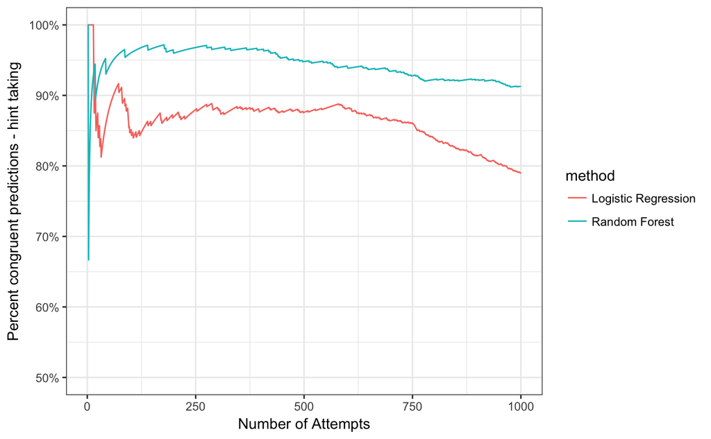

```r
##create a performance plot
test.1 <- test %>% mutate(first_action = as.integer(first_action)-1)
plot.data.rf <- test.1 %>% arrange(desc(rf.hint.pred.prob)) %>%
  mutate(numrank = row_number(), percent.first.action = cumsum(first_action)/numrank,
         method = rep("Random Forest",n())) %>%
  select(numrank, percent.first.action, method)
plot.data.lm <- test.1 %>% arrange(desc(re.lg.hint.pred.prob)) %>%
  mutate(numrank = row_number(), percent.first.action = cumsum(first_action)/numrank,
         method = rep("Logistic Regression",n())) %>%
  select(numrank, percent.first.action,method)
plot.data <- bind_rows(plot.data.rf,plot.data.lm)
##create plot
theme_set(theme_bw())
p <- ggplot(data=plot.data, aes(x=numrank, y=percent.first.action, col = method))
p <- p + geom_line()
p <- p + xlab('Number of Attempts') + xlim(1,1000)
p <- p + scale_y_continuous("Percent congruent predictions - hint taking", limits=c(0.5,1), labels=scales::percent)
p
```

# Part C: Bottom-out-Hint-Taking Prediction

```r
# forward stepwise selection
# error if includes tutor_mode, anwser_type
regfit.bh.fwd = regsubsets(bottom_hint ~ prev_total_correct +
                          prev_percent_correct + prev_problem_requested_hint +
                          prev_percent_problem_requested_hint + prev_avg_response_time +
                          prev_total_bottom_hint + prev_percent_bottom_hint +
                          prev_avg_attempt_count, data=train, nvmax=8, method="forward")
reg_bh_summary = summary(regfit.bh.fwd)
reg_bh_summary
```

```
Subset selection object
Call: regsubsets.formula(bottom_hint ~ prev_total_correct + prev_percent_correct +
    prev_problem_requested_hint + prev_percent_problem_requested_hint +
    prev_avg_response_time + prev_total_bottom_hint + prev_percent_bottom_hint +
    prev_avg_attempt_count, data = train, nvmax = 8, method = "forward")
8 Variables  (and intercept)
                                    Forced in Forced out
prev_total_correct                      FALSE      FALSE
prev_percent_correct                    FALSE      FALSE
prev_problem_requested_hint             FALSE      FALSE
prev_percent_problem_requested_hint     FALSE      FALSE
prev_avg_response_time                  FALSE      FALSE
prev_total_bottom_hint                  FALSE      FALSE
prev_percent_bottom_hint                FALSE      FALSE
prev_avg_attempt_count                  FALSE      FALSE
1 subsets of each size up to 8
Selection Algorithm: forward
         prev_total_correct prev_percent_correct prev_problem_requested_hint prev_percent_problem_requested_hint
1  ( 1 ) " "                " "                  " "                         " "
2  ( 1 ) " "                " "                  " "                         " "
3  ( 1 ) " "                "*"                  " "                         " "
4  ( 1 ) "*"                "*"                  " "                         " "
5  ( 1 ) "*"                "*"                  " "                         " "
6  ( 1 ) "*"                "*"                  "*"                         " "
7  ( 1 ) "*"                "*"                  "*"                         "*"
8  ( 1 ) "*"                "*"                  "*"                         "*"
         prev_avg_response_time prev_total_bottom_hint prev_percent_bottom_hint prev_avg_attempt_count
1  ( 1 ) " "                    " "                    "*"                      " "
2  ( 1 ) " "                    "*"                    "*"                      " "
3  ( 1 ) " "                    "*"                    "*"                      " "
4  ( 1 ) " "                    "*"                    "*"                      " "
5  ( 1 ) "*"                    "*"                    "*"                      " "
6  ( 1 ) "*"                    "*"                    "*"                      " "
7  ( 1 ) "*"                    "*"                    "*"                      " "
8  ( 1 ) "*"                    "*"                    "*"                      "*"
```

## Examine the results of stepwise selection and identify optimal number of features

```r
test.mat.bh = model.matrix(bottom_hint ~ prev_total_correct +
                          prev_percent_correct + prev_problem_requested_hint +
                          prev_percent_problem_requested_hint + prev_avg_response_time +
                          prev_total_bottom_hint + prev_percent_bottom_hint +
                          prev_avg_attempt_count, data=test)
val.errors=rep(NA,8)
for (i in 1:8){
  coefi=coef(regfit.bh.fwd, id=i)
  pred=test.mat.bh[,names(coefi)]%*%coefi
  val.errors[i]=mean((as.integer(test$bottom_hint)-pred)^2)
}
val.errors
```

```
[1] 0.1050548 0.1047905 0.1046065 0.1045471 0.1045329 0.1045226 0.1045155 0.1045115
```

```r
which.min(val.errors)
```

```
[1] 8
```

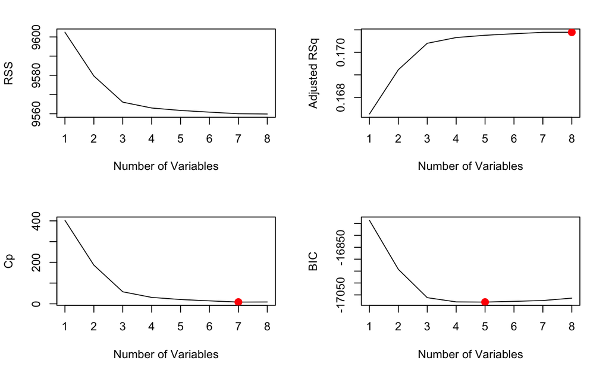

```r
# plots to examine RSS, R2, Cp and BIC
par(mfrow=c(2,2))
{plot(reg_bh_summary$rss, xlab = "Number of Variables", ylab = "RSS", type = "l")
plot(reg_bh_summary$adjr2, xlab = "Number of Variables", ylab = "Adjusted RSq", type = "l")
adj_r2_max = which.max(reg_bh_summary$adjr2)
points(adj_r2_max, reg_bh_summary$adjr2[adj_r2_max], col ="red", cex = 2, pch = 20)
plot(reg_bh_summary$cp, xlab = "Number of Variables", ylab = "Cp", type = "l")
cp_min = which.min(reg_bh_summary$cp) # 10
points(cp_min, reg_bh_summary$cp[cp_min], col = "red", cex = 2, pch = 20)
plot(reg_bh_summary$bic, xlab = "Number of Variables", ylab = "BIC", type = "l")
bic_min = which.min(reg_bh_summary$bic) # 6
points(bic_min, reg_bh_summary$bic[bic_min], col = "red", cex = 2, pch = 20)}
```

the model with the following seven features were selected based on the results; features included: prev_total_correct, prev_problem_requested_hint, prev_percent_problem_requested_hint, prev_avg_response_time, prev_total_bottom_hint, prev_percent_bottom_hint, prev_percent_correct features excluded: prev_avg_attempt_count

```r
# fit the model with the following features
# prev_total_correct
# prev_problem_requested_hint
# prev_percent_problem_requested_hint
# prev_avg_response_time
# prev_total_bottom_hint
# prev_percent_bottom_hint
re_lg_bottom_hint <- glm(bottom_hint ~ prev_total_correct +
                           prev_problem_requested_hint +
                           prev_percent_problem_requested_hint +
                           prev_avg_response_time +
                           prev_total_bottom_hint +
                           prev_percent_bottom_hint +
                           prev_percent_correct,
                          data=train, family="binomial")
#compute AUC of this model on the test dataset
test$re.lg.bottom.hint.pred.prob <- predict(re_lg_bottom_hint,newdata=test,type='response')
test.re.lg.bottom.hint.pred <- prediction(test$re.lg.bottom.hint.pred.prob, test$bottom_hint)
test.re.lg.bottom.hint.perf <- performance(test.re.lg.bottom.hint.pred, "auc")
cat('the auc score is ', 100*test.re.lg.bottom.hint.perf@y.values[[1]], "\n")
```

```
the auc score is  77.70773
```

```r
#calculate the five smallest and five largest coefficients
re_lg_bottom_hint_coef <- summary(re_lg_bottom_hint)[["coefficients"]]
re_lg_bottom_hint_coef[order(re_lg_bottom_hint_coef[ , 1]), ]
```

```
                                         Estimate   Std. Error     z value      Pr(>|z|)
(Intercept)                         -1.894448e+00 7.412889e-02 -25.5561309 4.693347e-144
prev_percent_correct                -8.571135e-01 9.133709e-02  -9.3840686  6.347496e-21
prev_percent_problem_requested_hint -1.791483e-01 1.119194e-01  -1.6006894  1.094457e-01
prev_total_correct                  -4.448069e-04 1.304332e-04  -3.4102277  6.490867e-04
prev_avg_response_time              -1.295937e-06 2.367683e-07  -5.4734385  4.413860e-08
prev_problem_requested_hint          7.445872e-04 1.245782e-03   0.5976864  5.500492e-01
prev_total_bottom_hint               9.199009e-03 1.532955e-03   6.0008360  1.963042e-09
prev_percent_bottom_hint             3.756234e+00 9.621357e-02  39.0405845  0.000000e+00
```

The AUC of the revised logistic model predicting bottom_hint on the test dataset is 77.70773

```r
#fit a random forest model on train
rf_bottom_hint <- randomForest(bottom_hint ~ prev_total_correct +
                           prev_problem_requested_hint +
                           prev_percent_problem_requested_hint +
                           prev_avg_response_time +
                           prev_total_bottom_hint +
                           prev_percent_bottom_hint +
                           prev_percent_correct,
                          data=train, ntree=200, na.action=na.omit)
#compute AUC of this model on the test dataset
test$rf.bottom.hint.pred.prob <- predict(rf_bottom_hint,newdata=test,type='prob')[,2]
test.rf.bottom.hint.pred <- prediction(test$rf.bottom.hint.pred.prob, test$bottom_hint)
test.rf.bottom.hint.perf <- performance(test.rf.bottom.hint.pred, "auc")
cat('the auc score is ', 100*test.rf.bottom.hint.perf@y.values[[1]], "\n")
```

```
the auc score is  80.513
```

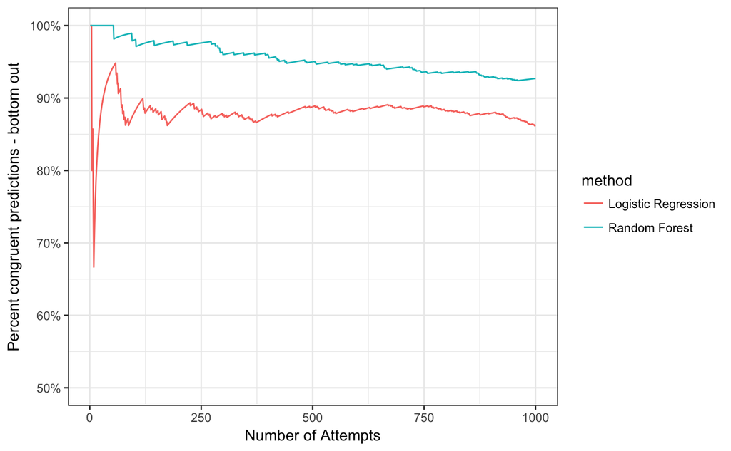

```r
#compares the performance of two models using the plots
##create a performance plot
test.bh <- test %>% mutate(bottom_hint = as.integer(bottom_hint)-1)
plot.data.rf.bh <- test.bh %>% arrange(desc(rf.bottom.hint.pred.prob)) %>%
  mutate(numrank = row_number(), percent.bottom.hint = cumsum(bottom_hint)/numrank,
         method = rep("Random Forest",n())) %>%
  select(numrank, percent.bottom.hint, method)
plot.data.lm.bh <- test.bh %>% arrange(desc(re.lg.bottom.hint.pred.prob)) %>%
  mutate(numrank = row_number(), percent.bottom.hint = cumsum(bottom_hint)/numrank,
         method = rep("Logistic Regression",n())) %>%
  select(numrank, percent.bottom.hint,method)
plot.data.bh <- bind_rows(plot.data.rf.bh,plot.data.lm.bh)
##create plot
theme_set(theme_bw())
p <- ggplot(data=plot.data.bh, aes(x=numrank, y=percent.bottom.hint, col = method))
p <- p + geom_line()
p <- p + xlab('Number of Attempts') + xlim(1,1000)
p <- p + scale_y_continuous("Percent congruent predictions - bottom out", limits=c(0.5,1), labels=scales::percent)
p
```

# Part D: Answer correctly Prediction

```r
#Removing problems in which hints were possbile
df_cor <- filter(df_fin,df_fin$hint_total==0)
#randomly shuffle the data
set.seed(1314)
df_cor <- df_cor %>% slice(sample(1:n()))
#create train_half and test_half
splitsize = floor(nrow(df_cor)/2)
train <- df_cor %>% slice(1:splitsize)
test <- df_cor %>% slice(splitsize+1:n())
```

```r
# forward stepwise selection
# error if includes anwser_type
regfit.c.fwd = regsubsets(correct ~ prev_total_correct +
                          prev_percent_correct + prev_problem_requested_hint +
                          prev_percent_problem_requested_hint + prev_avg_response_time +
                          prev_total_bottom_hint + prev_percent_bottom_hint +
                          prev_avg_attempt_count, data=train, method="forward")
reg_c_summary = summary(regfit.c.fwd)
reg_c_summary
```

```
Subset selection object
Call: regsubsets.formula(correct ~ prev_total_correct + prev_percent_correct +
    prev_problem_requested_hint + prev_percent_problem_requested_hint +
    prev_avg_response_time + prev_total_bottom_hint + prev_percent_bottom_hint +
    prev_avg_attempt_count, data = train, method = "forward")
8 Variables  (and intercept)
                                    Forced in Forced out
prev_total_correct                      FALSE      FALSE
prev_percent_correct                    FALSE      FALSE
prev_problem_requested_hint             FALSE      FALSE
prev_percent_problem_requested_hint     FALSE      FALSE
prev_avg_response_time                  FALSE      FALSE
prev_total_bottom_hint                  FALSE      FALSE
prev_percent_bottom_hint                FALSE      FALSE
prev_avg_attempt_count                  FALSE      FALSE
1 subsets of each size up to 8
Selection Algorithm: forward
         prev_total_correct prev_percent_correct prev_problem_requested_hint prev_percent_problem_requested_hint
1  ( 1 ) " "                "*"                  " "                         " "
2  ( 1 ) " "                "*"                  " "                         " "
3  ( 1 ) "*"                "*"                  " "                         " "
4  ( 1 ) "*"                "*"                  "*"                         " "
5  ( 1 ) "*"                "*"                  "*"                         " "
6  ( 1 ) "*"                "*"                  "*"                         " "
7  ( 1 ) "*"                "*"                  "*"                         "*"
8  ( 1 ) "*"                "*"                  "*"                         "*"
         prev_avg_response_time prev_total_bottom_hint prev_percent_bottom_hint prev_avg_attempt_count
1  ( 1 ) " "                    " "                    " "                      " "
2  ( 1 ) " "                    " "                    " "                      "*"
3  ( 1 ) " "                    " "                    " "                      "*"
4  ( 1 ) " "                    " "                    " "                      "*"
5  ( 1 ) " "                    "*"                    " "                      "*"
6  ( 1 ) "*"                    "*"                    " "                      "*"
7  ( 1 ) "*"                    "*"                    " "                      "*"
8  ( 1 ) "*"                    "*"                    "*"                      "*"
```

## Examine the results of stepwise selection and identify optimal number of features

```r
test.mat.c = model.matrix(correct ~ prev_total_correct +
                          prev_percent_correct + prev_problem_requested_hint +
                          prev_percent_problem_requested_hint + prev_avg_response_time +
                          prev_total_bottom_hint + prev_percent_bottom_hint +
                          prev_avg_attempt_count, data=test)
val.errors=rep(NA,8)
for (i in 1:8){
  coefi=coef(regfit.c.fwd, id=i)
  pred=test.mat.c[,names(coefi)]%*%coefi
  val.errors[i]=mean((as.integer(test$correct)-pred)^2)
}
val.errors
```

```
[1] 0.1875556 0.1874767 0.1874164 0.1873666 0.1873629 0.1873718 0.1873677 0.1873665
```

```r
which.min(val.errors)
```

```
[1] 5
```

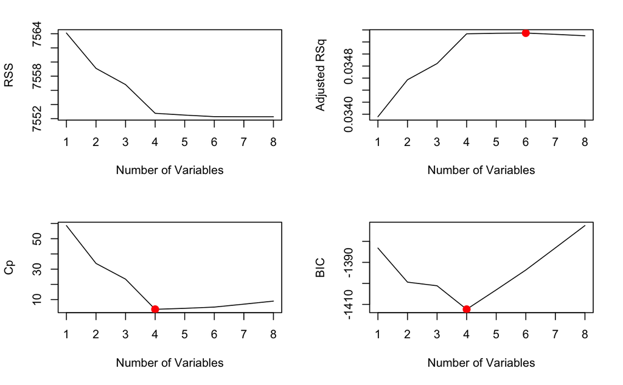

```r
par(mfrow=c(2,2))
{plot(reg_c_summary$rss, xlab = "Number of Variables", ylab = "RSS", type = "l")
plot(reg_c_summary$adjr2, xlab = "Number of Variables", ylab = "Adjusted RSq", type = "l")
adj_r2_max = which.max(reg_c_summary$adjr2)
points(adj_r2_max, reg_c_summary$adjr2[adj_r2_max], col ="red", cex = 2, pch = 20)
plot(reg_c_summary$cp, xlab = "Number of Variables", ylab = "Cp", type = "l")
cp_min = which.min(reg_c_summary$cp) # 10
points(cp_min, reg_c_summary$cp[cp_min], col = "red", cex = 2, pch = 20)
plot(reg_c_summary$bic, xlab = "Number of Variables", ylab = "BIC", type = "l")
bic_min = which.min(reg_c_summary$bic) # 6
points(bic_min, reg_c_summary$bic[bic_min], col = "red", cex = 2, pch = 20)}
```

the model with the following four features were selected based on the results; features included: prev_total_correct, prev_percent_correct, prev_problem_requested_hint, prev_avg_attempt_count features excluded: prev_total_bottom_hint, prev_percent_bottom_hint, prev_avg_response_time, prev_percent_problem_requested_hint

```r
# fit the model based on the results from forward stepwise selection by including 4 features
# prev_total_correct
# prev_percent_correct
# prev_percent_problem_requested_hint
# prev_percent_bottom_hint
re_lg_correct <- glm(correct ~ prev_total_correct +
                           prev_percent_correct +
                           prev_problem_requested_hint +
                           prev_avg_attempt_count,
                          data=train, family="binomial")
#compute AUC of this model on the test dataset
test$re.lg.correct.pred.prob <- predict(re_lg_correct,newdata=test,type='response')
test.re.lg.correct.pred <- prediction(test$re.lg.correct.pred.prob, test$correct)
test.re.lg.correct.perf <- performance(test.re.lg.correct.pred, "auc")
cat('the auc score is ', 100*test.re.lg.correct.perf@y.values[[1]], "\n")
```

```
the auc score is  63.06135
```

```r
#calculate the five smallest and five largest coefficients
re_lg_correct_coef <- summary(re_lg_correct)[["coefficients"]]
re_lg_correct_coef[order(re_lg_correct_coef[ , 1]), ]
```

```
                                 Estimate   Std. Error   z value      Pr(>|z|)
(Intercept)                 -0.3890860076 0.0592617375 -6.565552  5.184053e-11
prev_avg_attempt_count      -0.0539139144 0.0120753127 -4.464805  8.014178e-06
prev_problem_requested_hint -0.0033840642 0.0006345933 -5.332650  9.678961e-08
prev_total_correct           0.0006967437 0.0001283410  5.428847  5.671942e-08
prev_percent_correct         2.0964343019 0.0769880293 27.230653 2.816974e-163
```

the auc score is 63.06135

```r
#fit a random forest model on train
rf_correct <- randomForest(correct ~ prev_total_correct +
                           prev_percent_correct +
                           prev_problem_requested_hint +
                           prev_avg_attempt_count,
                          data=train, ntree=200, na.action=na.omit)
#compute AUC of this model on the test dataset
test$rf.correct.pred.prob <- predict(rf_correct,newdata=test,type='prob')[,2]
test.rf.correct.pred <- prediction(test$rf.correct.pred.prob, test$correct)
test.rf.correct.perf <- performance(test.rf.correct.pred, "auc")
cat('the auc score is ', 100*test.rf.correct.perf@y.values[[1]], "\n")
```

```
the auc score is  61.27778
```

the auc score is 61.27778

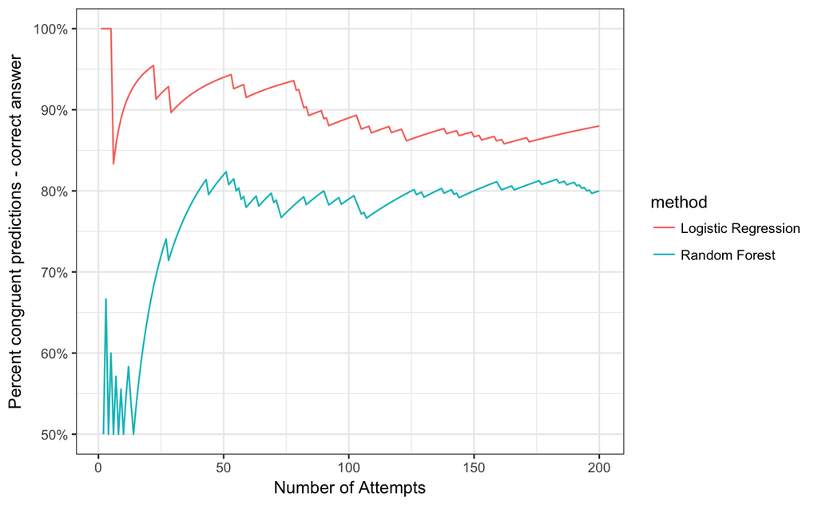

```r
#compares the performance of two models using the plots
##create a performance plot
test.correct <- test %>% mutate(correct = as.integer(correct)-1)
plot.data.rf.correct <- test.correct %>% arrange(desc(rf.correct.pred.prob)) %>%
  mutate(numrank = row_number(), percent.correct = cumsum(correct)/numrank,
         method = rep("Random Forest",n())) %>%
  select(numrank, percent.correct, method)
plot.data.lm.correct <- test.correct %>% arrange(desc(re.lg.correct.pred.prob)) %>%
  mutate(numrank = row_number(), percent.correct = cumsum(correct)/numrank,
         method = rep("Logistic Regression",n())) %>%
  select(numrank, percent.correct,method)
plot.data.correct <- bind_rows(plot.data.rf.correct,plot.data.lm.correct)
##create plot
theme_set(theme_bw())
p <- ggplot(data=plot.data.correct, aes(x=numrank, y=percent.correct, col = method))
p <- p + geom_line()
p <- p + xlab('Number of Attempts') + xlim(1,200)
p <- p + scale_y_continuous("Percent congruent predictions - correct answer", limits=c(0.5,1), labels=scales::percent)
p
```